# ABD ’deki Kadın Çalısma Saatleri Veri Analizi

Muhammed PEKTAS - Cevher SOYLEMEZ

##### Berk Orbay ve Mustafa Aydoğan’a teşekkür ederiz.

*Veriler 1995 yılında ABD’den toplanmistir.*

# HAZIRLIK

Gerekli paketlerin yuklenmesi;

```r
#install.packages("tidyverse")
library(tidyverse)
library(rpart)
library(rpart.plot)
```

yazildigi sekildedir.

Veri setimizi kullanmak istediğimiz bir format’a cevirmek icin;

```r
veriseti <- read.csv("wife_working_dataset.csv",header = TRUE,sep = ',')
veriseti <- veriseti[-1]
veriseti <- veriseti[-11]
veriseti <- veriseti %>% filter(veriseti$income>0)
Children=select(veriseti,child5:child17)
veriseti <- data.frame(veriseti,TotalChild=rowSums(Children))
```

kod satırlarını kullanıyoruz..

# ANALIZ

### Bazı İstatistiksel Cikarimlar

Kadinların ortalama calisma saatleri asagidaki kod yardimiyla yillik *1135.47* oldugunu goruyoruz.

```r
ortalama_calisma_suresi <- mean(veriseti$hours)
```

Calisan kadinlarin calismayan kadinlara orani; aşagidaki kod satirlari kullanılarak *2.7575* bulunmustur.

```r
calismayan_kadinlar <- veriseti %>% filter(veriseti$hours==0)
calisan_kadinlar <- veriseti %>% filter(veriseti$hours!=0)
clsn_clsmn_oran <- nrow(calisan_kadinlar)/nrow(calismayan_kadinlar)
```

> Bu durumda 1995 yilinda ABD’de calisan kadinlarin calismayan kadinlardan *yaklasik 3 kat fazla* oldugunu goruyoruz.

### Grafiksel Yaklasimlar

İlk olarak kadınların yıllık calisma sureleri ile 0-5 yaş aralığındaki çocuk sayıları arasındaki ilişkiyi inceleceyelim.

*0-5 Yaş Aralığı

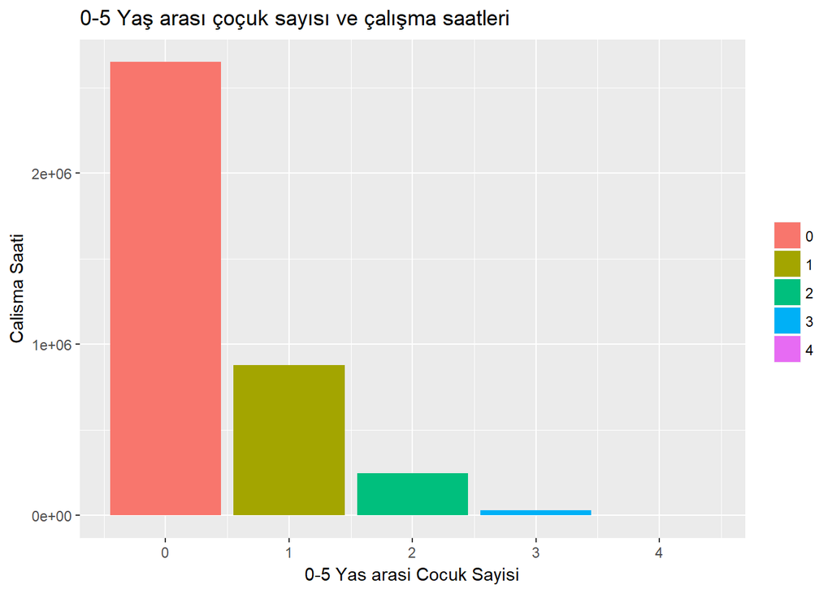

```r
ggplot(veriseti,aes(x=child5,y=hours)) + geom_bar(stat="identity",aes(fill=as.factor(child5)))+ggtitle("0-5 Yaş arası çoçuk sayısı ve çalışma saatleri")+xlab("0-5 Yas arasi Cocuk Sayisi")+ylab("Calisma Saati")+theme(legend.title=element_blank())
```

Aşağıdaki kod bloğunda ise kadınların eğitim durumlarına göre ortalama çalışma saatleri gösterilmiştir.

*Eğitim - Çalışma Saati

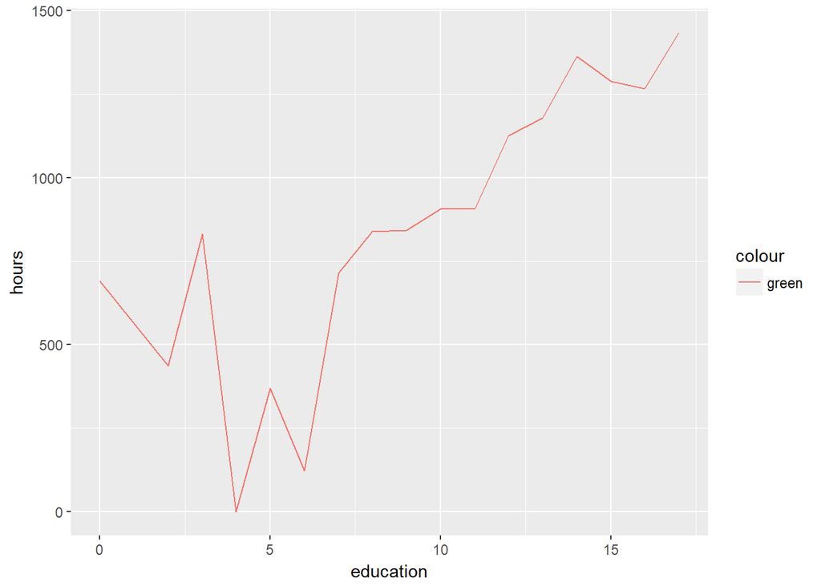

```r
eduHour <-veriseti %>% group_by(education) %>%
  summarise_at(vars(hours),funs(mean))

ggplot(eduHour,aes(x=education,y=hours))+geom_line(aes(colour="green"))
```

> Bu grafikten kadınların 0-5 yıl eğitim alanlarının ortalama çalışma saatleri değişkenlik gösterse de bu eşikten sonra eğitim süresi arttıkça ortalama çalışma saatlerinin de arttığını görüyoruz.

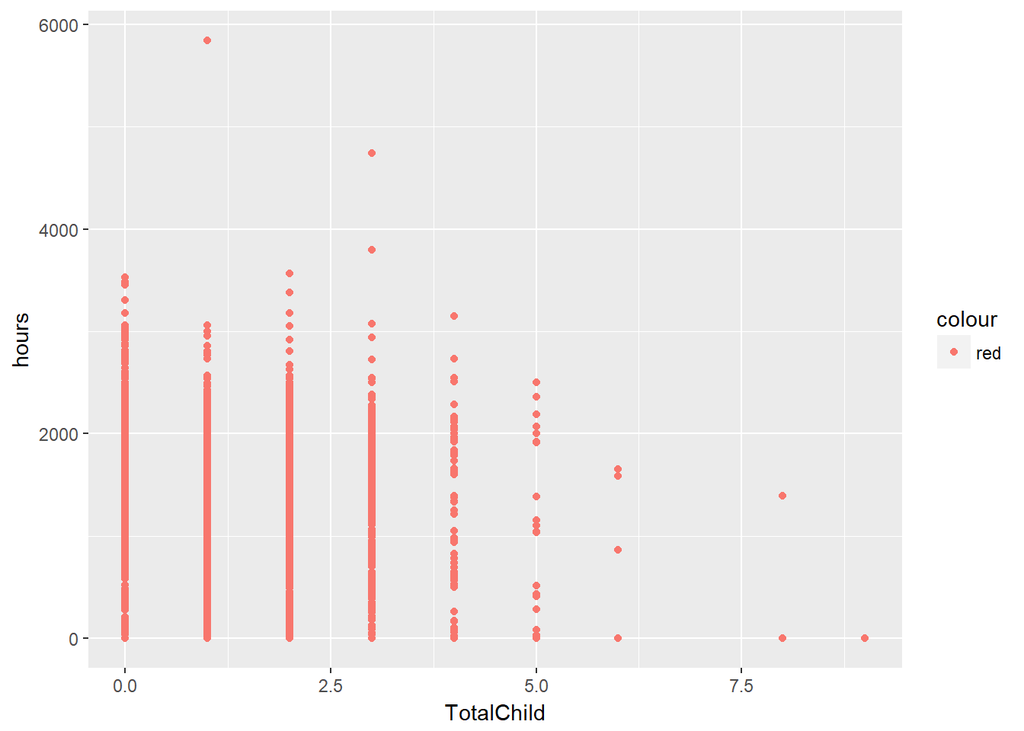

```r
ggplot(veriseti,aes(x=TotalChild,y=hours))+geom_point(aes(color='red'))
```

> Toplam çoçuk sayıları arttıkça çalışan kadınların sayısının azalmasıyla beraber ortalama çalışma saatlerinin de azaldığı görülmektedir.

### Tahminsel Yaklaşımlar

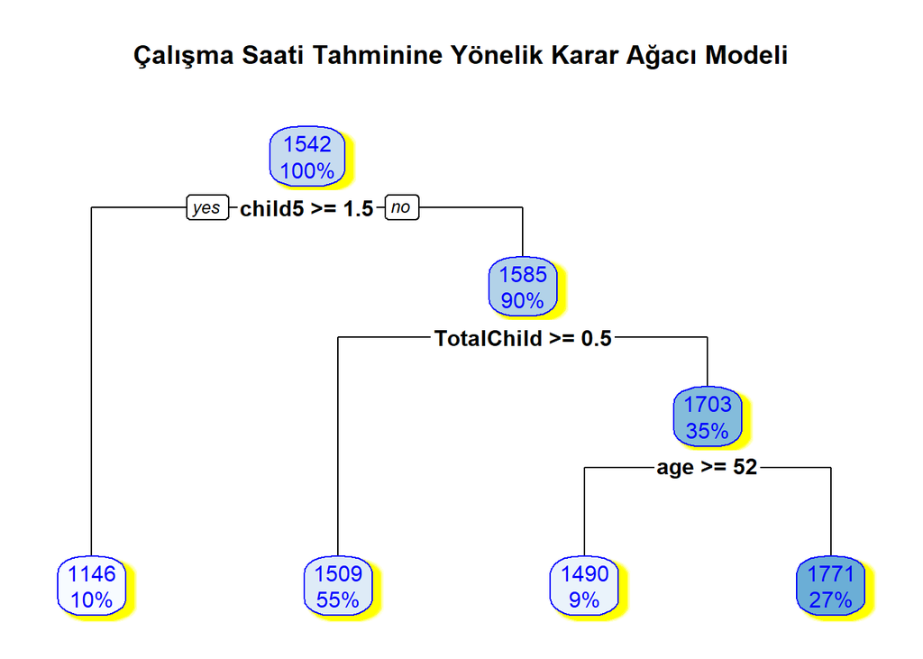

```r
calisan_kadinlar <- veriseti %>% filter(veriseti$hours!=0)
agacmodeli = rpart(hours~.,calisan_kadinlar)
rpart.plot(agacmodeli,main="Çalışma Saati Tahminine Yönelik Karar Ağacı Modeli",shadow.col = "yellow",col="blue")
```

Yukarıda çalışma saatinin tahminine yönelik karar ağacı modeli çizilmiştir.  
>Bu modele göre kadınların 0-5 yaş arasında 1 den fazla çocuğu olan kadınların diğerlerine göre daha az sürelerde çalıştığını görebiliyoruz. Ayrıca 52 yaşından küçük olanların büyük olanlara göre nispeten daha çok çalıştıklarını söyleyebiliriz.

#### Lineer Yaklaşım

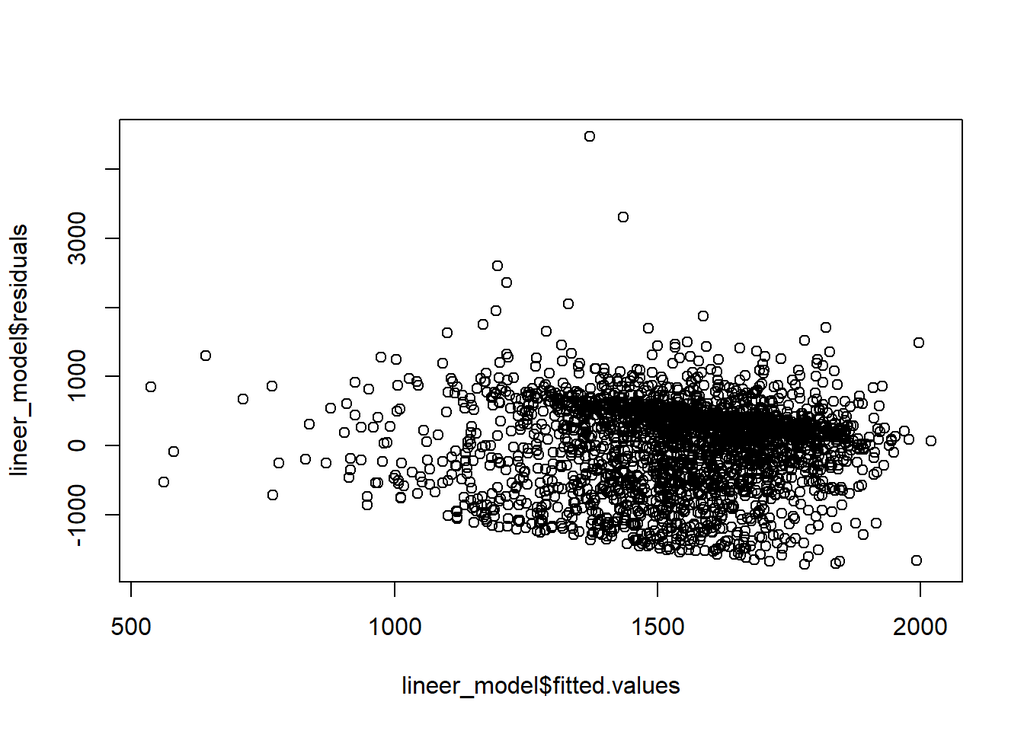

```r
require(data.table)
lineer_model = lm(hours~.,calisan_kadinlar)
#plot(calisan_kadinlar$hours, lineer_model$fitted.values, xlab = "Gercek Deger", ylab = "Tahmini Deger")
plot(lineer_model$fitted.values,lineer_model$residuals)
```